# Integration site summary for dataset ‘test-merge’

Wed 28 Jul 2021

## Overview

This report gives an overview of the integration sites detected for the dataset called test-merge

## Analysis parameters

### Samples

The dataset `test-merge` consisted of the following samples:

- `cond0.rep0`

### Preprocessing

Reads were provided in `fasta format`. The reads were de-duplciated using `Dedeupe` from the `BBTools` suite, had adapters trimmed and overlapping R1 and R2 merged using `SeqPrep` before alignment.

### Alignment

The virus was `rep68` (provided in fasta format), with one contig: lcl|NC_001401.2_cds_YP_680422.1_1.

Alignments were conducted with `bwa mem` using parameters `-a -Y -A 1 -B 2 -O 6,6 -E 1,1 -L 0,0 -T 10 -h 200`. See the [man page](http://bio-bwa.sourceforge.net/bwa.shtml) for a full description of these parameters.

Fragment sizes from the alignments are used to calculate an approximate integration location for discordant pairs, in which the actual junction is not directly observed. The following mean fragment lengths were calculated using `samtools stat` for each sample:

| sample | host | virus | mean |
| --- | --- | --- | --- |
| cond0.rep0 | 220 | 288 | 254 |

### Postprocessing

After identification, integration junctions were junctions that met all of the following criteria were retained:

- `HostEditDist <= 5`
- `ViralEditDist <= 5`
- `NoAmbiguousBases < 20 or Type == discordant`
- `PossibleVectorRearrangement == False`
- `PossibleHostTranslocation == False`

Retained junctions were split into groups on the basis of confidence in their locations. Junctions had a unique location if the mapping quality for the alignment to a reference was above 20, and if they didn’t have any other possible mapping locations. Other possible mapping locations come from secondary or supplementary alignments that are similar to the primary alignment in terms of part of the read covered and edit distance (primary edit distance at most 60% of the secondary/supplementary one), but are in a different part of the genome to the primary alignment.

Unique integration junctions with overlapping coordinates in host and virus genomes were then merged, and merged junctions with at least 1 supporting reads were retained.

## Number of host/virus junctions identified

Isling identifies host/virus junctions in chimeric reads and discordant pairs. First, looking at the number of junctions identified - note that this is the total number of jucntions, before combining any integration junctions with the same coordinates, and is essentially a count of the nubmer of read (pairs) in which junctions were identfied (except in the case where there was more than one jucntion per read). This number can differ from the true number of integration events in the dataset if there are PCR duplicates (for example in amplicon datasets), or clonal expansion in the dataset.

First, count the number of host/virus junctions identified in chimeric reads or discordant read-pairs.

| sample | junctions passing filters | total putative junctions | junctions failing filters |
| --- | --- | --- | --- |
| cond0.rep0 | 27 | 40 | 13 |

There were a total of 27 junctions identified for this dataset.

All samples had at least one host/virus junction that passed all filters.

## Junction types

For this section, we examine all the integration junctions retained after filtering. Each junction has a number of properties associated with it. In this section we examine some of those properties.

### Chimeric reads and discordant pairs

Counting the number of junctions that were observed in chimeric reads and discordant pairs. For chimeric reads, we further stratify in the junction had a ‘gap’, ‘overlap’ or was a ‘clean’ junction.

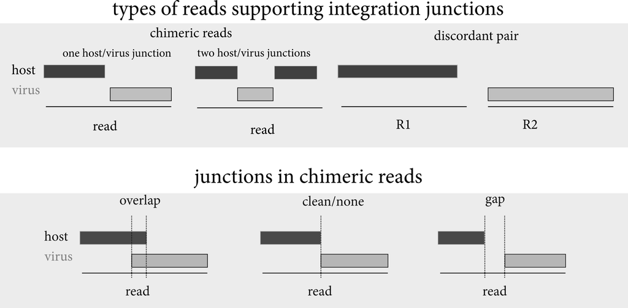

Types of reads supporting integration junctions and junction types

We call any bases involved in a gap or overlap ‘ambiguous bases’, and since it is not possible to identify a precise location within those ambiguous bases, *isling* reports the coordinates of the bases as the location of the integration.

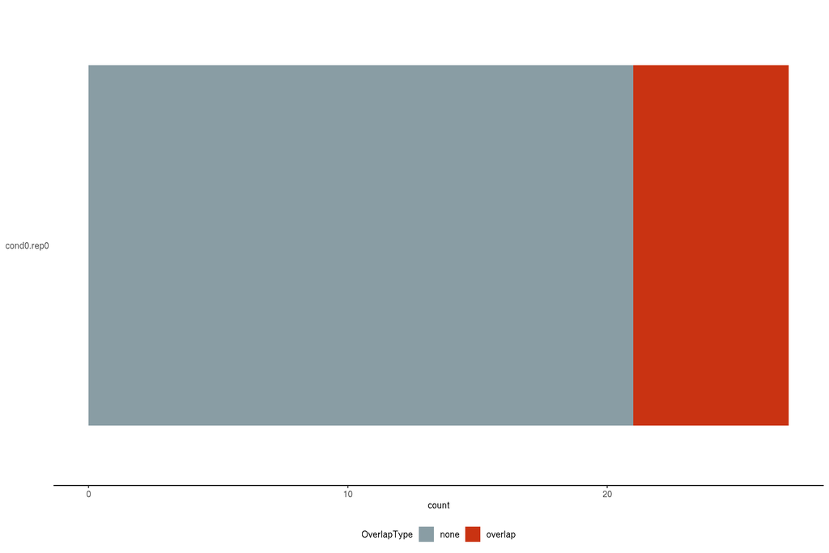

If the junction is ‘gap’ or ‘overlap’, it has an associated number of ambiguous bases associated with it. The distribution of the number of ambiguous bases looks like this (note that this frequency polynomial is normalised so the area under each curve is the same for all samples).

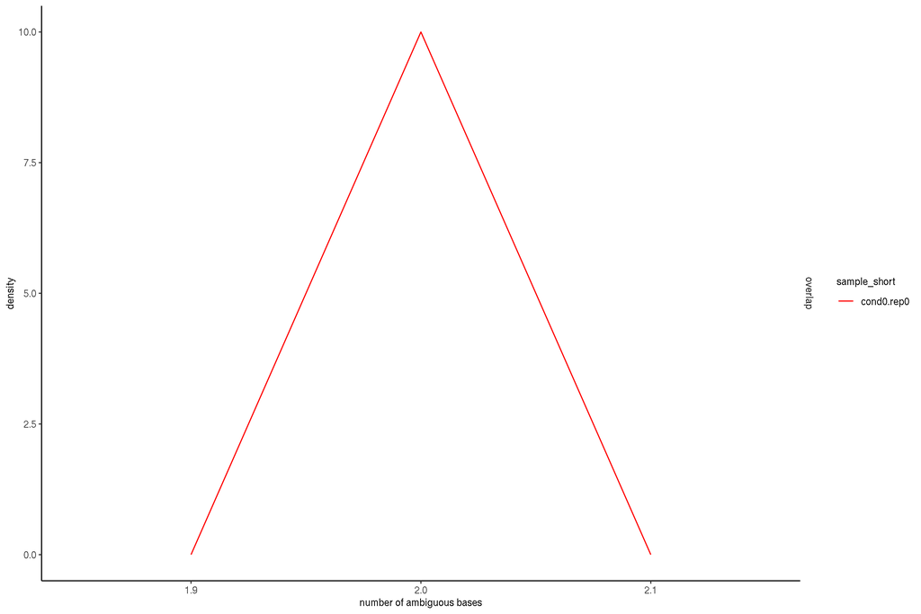

### Ambiguous/unique locations

We can also count the number of junctions that can be uniquely localised in both host and virus genomes, and those with locations that are ambiguous in one or both genomes.

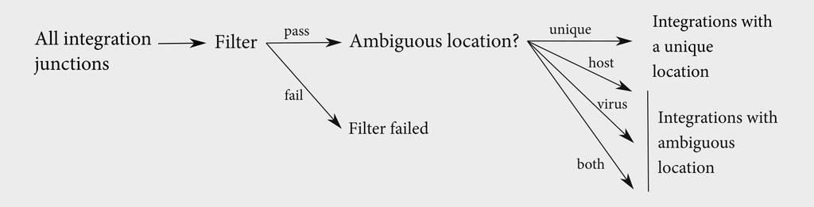

Post-processing steps

Note the distinction between ‘ambiguous bases’, which refer to the bases that are part of a gap or overlap at an individual integration junction, and ‘ambiguous location’, which refers to host or viral alignments which cannot be uniquely localised in the respective genome. These ambiguous locations occur because the mapping quality of the alignment is low, or because there are multiple best alignments for the read.

We divide integrations into four groups, depending on their locations in host and viral references:

| Group | Host location | Virus location |
| --- | --- | --- |
| Unique | Unambiguous | Unambiguous |
| Ambiguous (host) | Ambiguous | Unambiguous |
| Ambiguous (virus) | Unambiguous | Ambiguous |
| Ambiguous (both) | Ambiguous | Ambiguous |

Counting the number of junctions in each of these four groups:

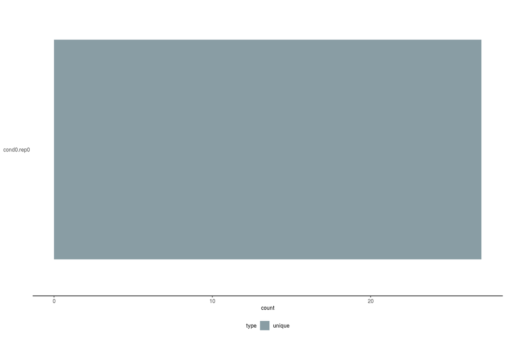

### Location in viral reference(s)

We first plot the number of integration junctions identified in each viral reference.

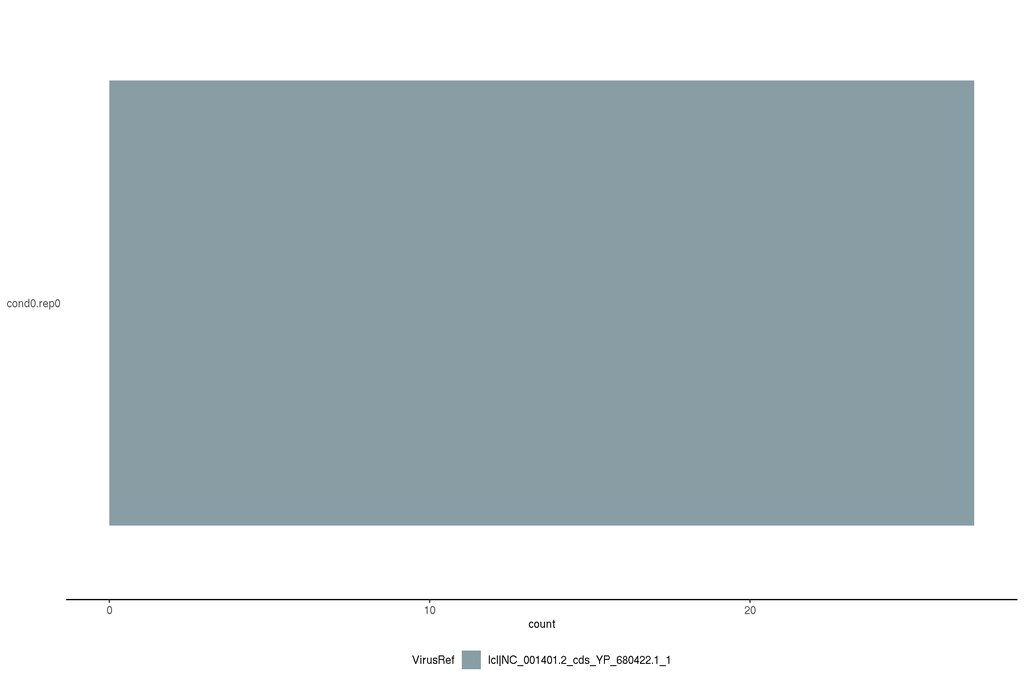

We can also plot the location of integration junctions in each viral reference. Since it’s hard to visualise very many viral references, this plot is limited to the 25 viral references that harbor the most integration junctions.

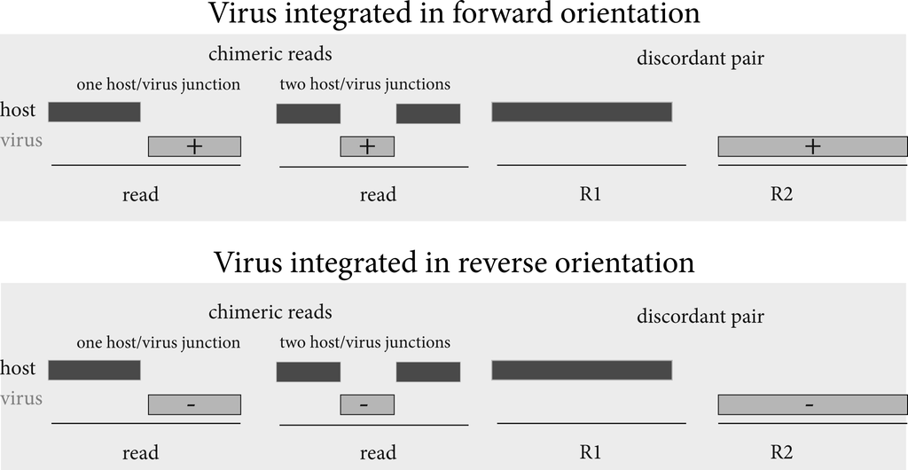

Virus orientatioins

For each viral reference, the rectangles above the axis for each viral reference represent the coordinates of junctions where the virus as integrated in the forward (+) orientation, and those below the axis represent integrations in the reverse (-) direction. Integration jucntions in red were observed in chimeric reads, and integration junctions in grey were observed in discordant pairs (and therefore represent approximate junction locations).

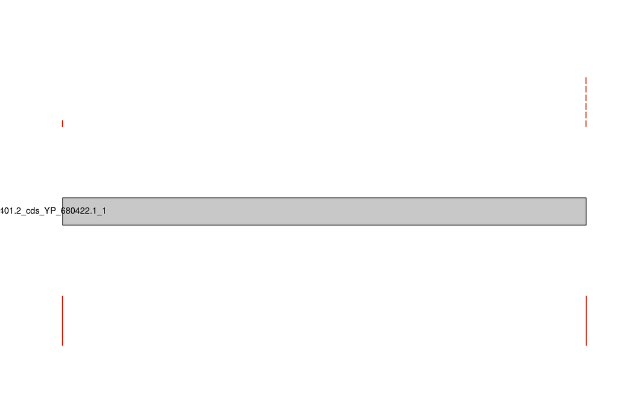

### Location in host genome

We can also look at the location of integration junctions in the host genome - for this we use the integration junctions that have a unique location in the host genome (the ‘unique’ and ‘ambiguous (viral)’ subsets).

First, count the number of integrations on each contig in the host reference:

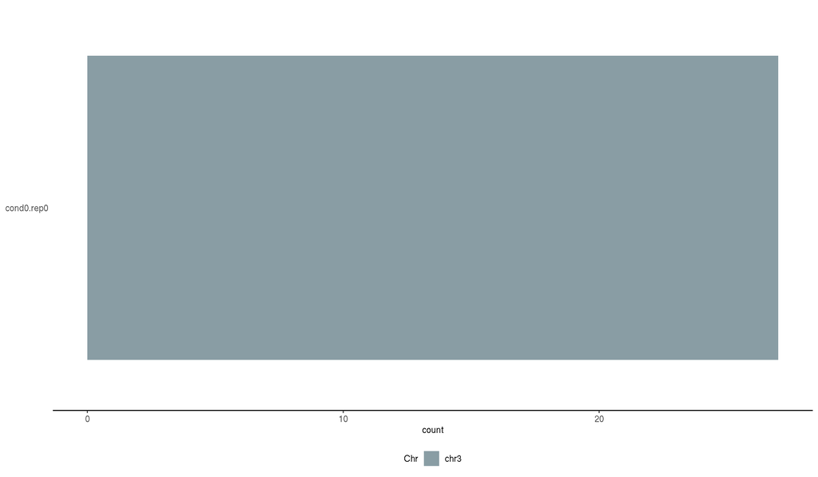

Next, we plot the location of the integrations in the host genome. Since a lot of contigs can make this plot difficult to view, we only use the top 25 contigs (ranked by number of integrations).

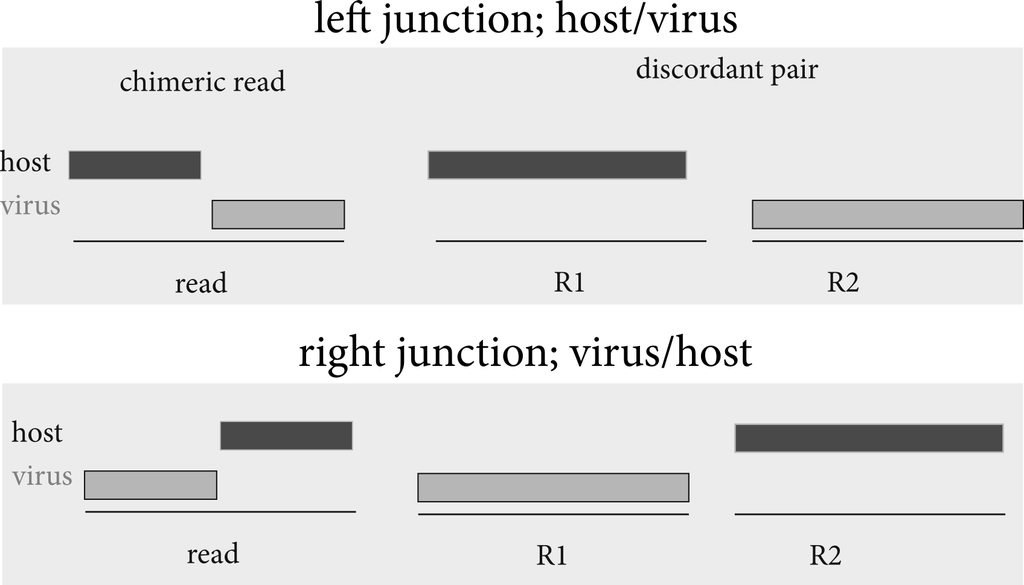

Host orientatioins

Similar to above, we plot the integration coordinates for left, or host/virus junctions, on top, and those for right or virus/host junctions below. Again, integration jucntions in red were observed in chimeric reads, and integration junctions in grey were observed in discordant pairs (and therefore represent approximate junction locations).

[figure not shown]